# Multiple Hypothesis Testing

Omid Shams Solari

Spring 2019, STAT200B

# Procedures

p-values are not a useful quantity for inference when dealing with high-dimensional data. This is because we are testing many features at the same time. This is the *multiple comparison* or multiple testing or multiplicity problem. Since we test many hypotheses simultaneously, a list based simply on a small p-value cut-off of, say 0.01, can result in many false positives with high probability. Here we introduce new notions that’ll help us with this problem.

A common approach to the multiplicity problem is to define a procedure and then estimate or *control* an informative error rate for this procedure. What we mean by *control* here is that we adapt the procedure to guarantee a error rate below a certain value. The procedures are typically flexible through parameters or cutoffs that let us control specificity and sensitivity. An example of a procedure is:

- Compute a p-value for each hypothesis.
- Call significant all tests with p-values smaller than $\alpha$.

Through the parameter $\alpha$ one may adjust specificity and sensitivity.

Next we define the error rates that we will try to estimate and control.

## Error Rates

Throughout this section we will be using the type I error and type II error terminology. We will also refer to them as *false positives* and *false negatives* respectively. We also use the more general terms *specificity*, which relates to type I error, and *sensitivity*, which relates to type II errors.

In the context of multiple testing, e.g. in high-throughput data, we can make several type I errors and several type II errors in one experiment. In this table, we summarize the possibilities using the notation from the seminal paper by Benjamini-Hochberg:

|  | Called significant | Not called significant | Total |
| --- | --- | --- | --- |
| Null True | $V$ | $m_0 - V$ | $m_0$ |
| Alternative True | $S$ | $m_1-S$ | $m_1$ |
| True | $R$ | $m-R$ | $m$ |

To describe the entries in the table, let’s use as an example a dataset representing measurements from 10,000 genes, which means that the total number of tests that we are conducting is: $m=10,000$. The number of genes for which the null hypothesis is true, which in most cases represent the “uninteresting” genes, is $m_0$, while the number of genes for which the null hypothesis is false is $m_1$. For this we can also say that the alternative hypothesis is true. In general, we are interested in detecting as many as the cases for which the alternative hypothesis is true (true positives), without incorrectly detecting cases for which the null hypothesis is true (false positives). For most high-throughput experiments, we assume that $m_0$ is much greater than $m_1$. For example, we test 10,000 expecting 100 genes or less to be interesting. This would imply that $m_1 \leq 100$ and $m_0\geq 9900$.

Throughout this chapter we refer to features as the units being tested. In genomics, examples of features are genes, transcripts, binding sites, CpG sites, and SNPs. In the table, $R$ represents the total number of features that we call significant after applying our procedure, while $m-R$ is the total number of genes we don’t call significant. The rest of the table contains important quantities that are unknown in practice.

- $V$ represents the number of type I errors or false positives. Specifically, $V$ is the number of features for which the null hypothesis is true, that we call significant.
- $S$ represents the number of true positives. Specifically, $S$ is the number of features for which the alternative is true, that we call significant.

This implies that there are $m_1 - S$ type II errors or false negatives and $m_0 - V$ true negatives.

*Note: If we only ran one test, a p-value is simply the probability that $V=1$ when $m=m0=1$. Power is the probability of $S=1$ when $m=m1=1$. In this very simple case, we wouldn’t bother making the table above, but now we show how defining the terms in the table helps in practice the high-dimensional context.*

## Data example

Let’s compute these quantities with a data example. We will use a Monte Carlo simulation using our mice data to imitate a situation in which we perform tests for 10,000 different fad diets, none of them having an effect on weight. This implies that the null hypothesis is true for diets and thus $m = m_0 = 10,000$ and $m_1 = 0$. Let’s run the tests with a sample size of $N = 12$ and compute R. Our procedure will declare any diet achieving a p-value smaller than $\alpha = 0.05$ as significant.

```r
set.seed(1)
population = unlist( read.csv("femaleControlsPopulation.csv") )
alpha <- 0.05
N <- 12
m <- 10000
pvals <- replicate(m,{
  control = sample(population,N)
  treatment = sample(population,N)
  t.test(treatment,control)$p.value
})
```

Although in practice we do not know the fact that no diet works, in this simulation we do, and therefore we can actually compute V and S. Because all null hypotheses are true, we know, in this specific simulation, that V=R. Of course, in practice we can compute R but not V.

```r
sum(pvals < 0.05)
```

```
## [1] 462
```

These many false positives are not acceptable in most contexts.

Here is more complicated code showing results where 10% of the diets are effective with an average effect size of $\Delta = 3$ ounces. Studying this code carefully will help understand the meaning of the table above. First let’s define the truth:

```r
alpha <- 0.05
N <- 12
m <- 10000
p0 <- 0.90 ##10% of diets work, 90% don't
m0 <- m*p0
m1 <- m-m0
nullHypothesis <- c( rep(TRUE,m0), rep(FALSE,m1))
delta <- 3
```

Now we are ready to simulate 10,000 tests, perform a t-test on each, and record if we rejected the null hypothesis or not:

```r
set.seed(1)
calls <- sapply(1:m, function(i){
  control <- sample(population,N)
  treatment <- sample(population,N)
  if(!nullHypothesis[i]) treatment <- treatment + delta
  ifelse( t.test(treatment,control)$p.value < alpha,
          "Called Significant",
          "Not Called Significant")
})
```

Because in this simulation we know the truth (saved in `nullHypothesis`), we can compute the entries of the table:

```r
null_hypothesis <- factor( nullHypothesis, levels=c("TRUE","FALSE"))
table(null_hypothesis,calls)
```

```
##                calls
## null_hypothesis Called Significant Not Called Significant
##           TRUE                 421                   8579
##           FALSE                520                    480
```

The first column of the table above shows us V and S. Note that V and S are random variables. If we run the simulation repeatedly, these values change. Here is a quick example:

```r
B <- 10 ##number of simulations
VandS <- replicate(B,{
  calls <- sapply(1:m, function(i){
    control <- sample(population,N)
    treatment <- sample(population,N)
    if(!nullHypothesis[i]) treatment <- treatment + delta
    t.test(treatment,control)$p.val < alpha
  })
  cat("V =",sum(nullHypothesis & calls), "S =",sum(!nullHypothesis & calls),"\n")
  c(sum(nullHypothesis & calls),sum(!nullHypothesis & calls))
  })
```

```
## V = 410 S = 564
## V = 400 S = 552
## V = 366 S = 546
## V = 382 S = 553
## V = 372 S = 505
## V = 382 S = 530
## V = 381 S = 539
## V = 396 S = 554
## V = 380 S = 550
## V = 405 S = 569
```

This motivates the definition of error rates. We can, for example, estimate probability that V is larger than 0. This is interpreted as the probability of making at least one type-I error among the 10,000 tests. In the simulation above, V was much larger than 1 in every single simulation, so we suspect this probability is very practically 1. When $m = 1$, this probability is equivalent to the p-value. When we have a multiple tests situation, we call it the Family Wise Error Rate (FWER) and it relates to a technique that is widely used: The Bonferroni Correction.

## The Bonferroni Correction

Now that we have learned about the Family Wide Error Rate (FWER), we describe what we can actually do to control it. In practice, we want to choose a procedure that guarantees the FWER is smaller than a predetermined value such as 0.05. We can keep it general and instead of 0.05, use $\alpha$ in our derivations.

Here we don’t know the truth anymore, hence we propose a procedure and try to estimate the FWER. Let’s consider the procedure: “reject all the hypotheses with $p-value < 0.01$”. For illustrative purposes we will assume all the tests are independent (in the case of testing diets this is a safe assumption; in the case of genes it is not so safe since some groups of genes act together). Let $p_1, \ldots ,p_{10000}$ be the the p-values we get from each test. These are independent random variables,

$$\begin{aligned}
Pr(at\ least\ one\ rejection) &=1 - Pr(no\ rejections)\\
&= 1-\prod_{i=1}^{10000}Pr(p_i>0.01)\\
&=1-0.99^{10000} \approx 1
\end{aligned}$$
Use simulation to estimate this probability.

```r
B<-10000
minpval <- replicate(B, min(runif(10000,0,1))<0.01)
mean(minpval>=1)
```

```
## [1] 1
```

So our FWER is 1! This is not what we were hoping for. If we wanted it to be lower than $\alpha = 0.05$, we failed.

So what do we do to make the probability of a mistake lower than $\alpha$? Using the derivation above we can change the procedure by selecting a more stringent cutoff, previously 0.01, to lower our probability of at least one mistake to be 5%. Namely, by noting that,

$$Pr(at\ least\ one\ rejection)=1-(1-k)^{10000}$$
and solving for $k$, we get $1-(1-k)^{10000} = 0.05 \Rightarrow k = 1 - 0.95^{1/10000} \approx 0.000005$

This now gives a specific example of a procedure. This one is actually called Sidak’s procedure. Specifically, we define a set of instructions, such as “reject all the null hypothesis for which p-values < 0.000005”. Then, knowing the p-values are random variables, we use statistical theory to compute how many mistakes, on average, we are expected to make if we follow this procedure. More precisely, we compute bounds on these rates; that is, we show that they are smaller than some predetermined value. There is a preference in the life sciences to err on the side of being conservative.

A problem with Sidak’s procedure is that it assumes the tests are independent. It therefore only controls FWER when this assumption holds. The Bonferroni correction is more general in that it controls FWER even if the tests are not independent. As with Sidak’s procedure we start by noting that:

$$FWER = Pr( V > 0 ) \leq Pr(V > 0\ |\ all\ nulls\ are\ true)$$
or using the notation from the table above:

$$Pr(V>0) \leq Pr(V > 0 |\ m_1 = 0)$$

$$\begin{aligned}
Pr( V > 0 | m_1 = 0) &= Pr( min_i\{p_i\} \leq \alpha /m | m_1 = 0)\\
& \leq \sum_{i=1}^m I(p_i \leq \alpha/m)\\
& = m \frac{\alpha}{m}= \alpha
\end{aligned}$$

Controlling the FWER at 0.05 is a very conservative approach. Now use the p-values in the previous section and the Bonferroni correction and find out how many nulls are rejected.

```r
set.seed(1)
pvals <- sapply(1:m, function(i){
  control <- sample(population,N)
  treatment <- sample(population,N)
  if(!nullHypothesis[i]) treatment <- treatment + delta
  t.test(treatment,control)$p.value
})
```

Total $m_0$,

```r
sum(pvals < 0.05/10000)
```

```
## [1] 2
```

are called significant after applying the Bonferroni procedure, despite having 1000 diets that work.

## False Discovery Rate

There are many situations for which requiring an FWER of 0.05 does not make sense as it is much too strict. For example, consider the very common exercise of running a preliminary small study to determine a handful of candidate genes. This is referred to as a discovery driven project or experiment. We may be in search of an unknown causative gene and more than willing to perform follow up studies with many more samples on just the candidates. If we develop a procedure that produces, for example, a list of 10 genes of which 1 or 2 pan out as important, the experiment is a resounding success. With a small sample size, the only way to achieve a $FWER \leq 0.05$ is with an empty list of genes. We already saw in the previous section that despite 1,000 diets being effective, we ended up with a list with just 2. Change the sample size to 6 and you very likely get 0,

```r
set.seed(1)
pvals <- sapply(1:m, function(i){
  control <- sample(population,6)
  treatment <- sample(population,6)
  if(!nullHypothesis[i]) treatment <- treatment + delta
  t.test(treatment,control)$p.value
  })
sum(pvals < 0.05/10000)
```

```
## [1] 0
```

By requiring a $FWER \leq 0.05$, we are practically assuring 0 power (sensitivity). In many applications, this specificity requirement is over-kill. A widely used alternative to the FWER is the *false discover rate (FDR)*. The idea behind FDR is to focus on the random variable $Q \equiv V/R$ with $Q=0$ when $R=0$ and $V=0$. Note that $R=0$ (nothing called significant) implies $V=0$ (no false positives). So $Q$ is a random variable that can take values between 0 and 1 and we can define a rate by considering the average of $Q$. To better understand this concept here, we compute Q for the procedure: call everything $p-value < 0.05$ significant.

### Vectorizing Code

Before running the simulation, we are going to vectortize the code. This means that instead of using `sapply` to run $m$ tests, we will create a matrix with all data in one call to sample. This code runs several times faster than the code above, which is necessary here due to the fact that we will be generating several simulations. Understanding this chunk of code and how it is equivalent to the code above using sapply will take a you long way in helping you code efficiently in R.

```r
library(genefilter) ##rowttests is here
set.seed(1)
##Define groups to be used with rowttests
g <- factor( c(rep(0,N),rep(1,N)) )
B <- 1000 ##number of simulations
Qs <- replicate(B,{
  ##matrix with control data (rows are tests, columns are mice)
  controls <- matrix(sample(population, N*m, replace=TRUE),nrow=m)

  ##matrix with control data (rows are tests, columns are mice)
  treatments <-  matrix(sample(population, N*m, replace=TRUE),nrow=m)

  ##add effect to 10% of them
  treatments[which(!nullHypothesis),]<-treatments[which(!nullHypothesis),]+delta

  ##combine to form one matrix
  dat <- cbind(controls,treatments)

 calls <- rowttests(dat,g)$p.value < alpha
 R=sum(calls)
 Q=ifelse(R>0,sum(nullHypothesis & calls)/R,0)
 return(Q)
})
```

### Controlling FDR

The code above is a Monte Carlo simulation that generates 10,000 experiments 1,000 times, each time saving the observed Q. Here is a histogram of these values,

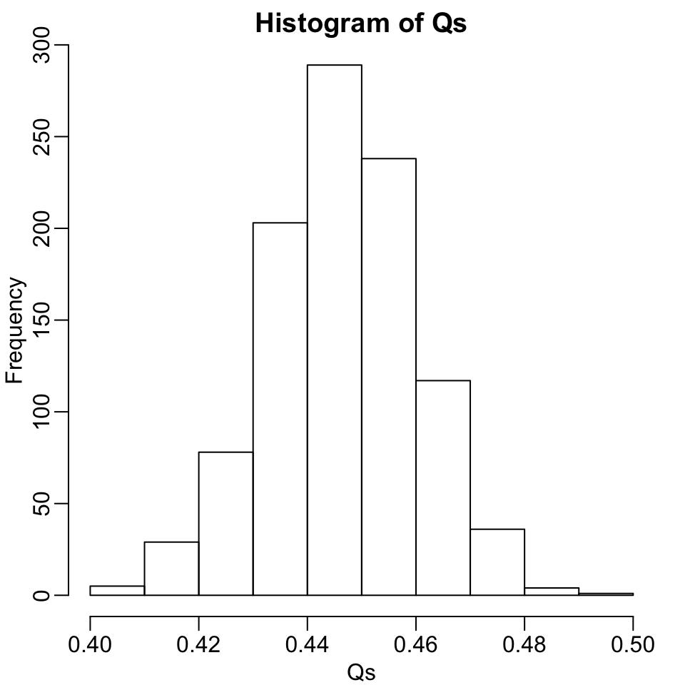

```r
library(rafalib)
mypar(1,1)
hist(Qs) ##Q is a random variable, this is its distribution
```

The FDR is the average value of $Q$.

```r
FDR=mean(Qs)
print(FDR)
```

```
## [1] 0.4463354
```

The FDR is relatively high here. This is because for 90% of the tests, the null hypotheses is true. This implies that with a 0.05 p-value cut-off, out of the 100 tests we incorrectly call between 4 and 5 significant on average. This combined with the fact that we don’t “catch” all the cases where the alternative is true, gives us a relatively high FDR. So how can we control this? What if we want lower FDR, say 5%?

To visually see why the FDR is high, we can make a histogram of the p-values. We use a higher value of $m$ to have more data from the histogram. We draw a horizontal line representing the uniform distribution one gets for the $m_0$ cases for which the null is true.

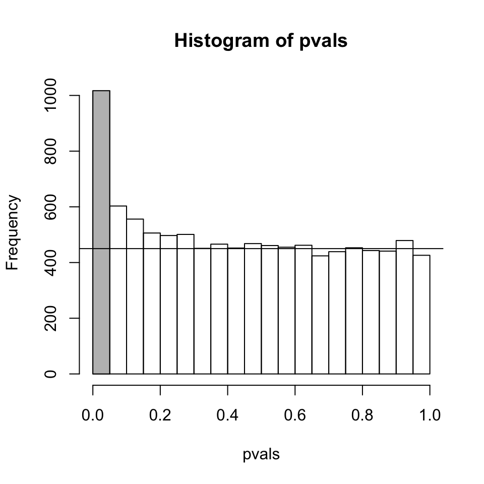

```r
set.seed(1)
controls <- matrix(sample(population, N*m, replace=TRUE),nrow=m)
treatments <-  matrix(sample(population, N*m, replace=TRUE),nrow=m)
treatments[which(!nullHypothesis),]<-treatments[which(!nullHypothesis),]+delta
dat <- cbind(controls,treatments)
pvals <- rowttests(dat,g)$p.value

h <- hist(pvals,breaks=seq(0,1,0.05))
polygon(c(0,0.05,0.05,0),c(0,0,h$counts[1],h$counts[1]),col="grey")
abline(h=m0/20)
```

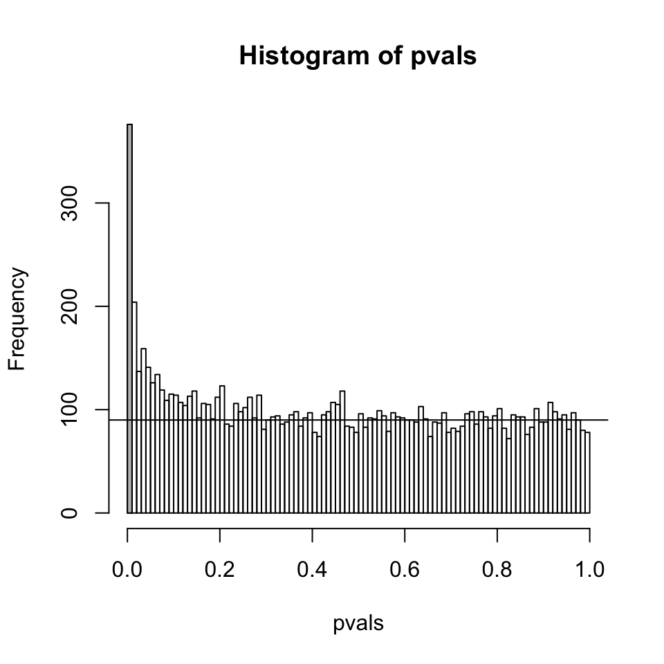

```r
h <- hist(pvals,breaks=seq(0,1,0.01))
polygon(c(0,0.01,0.01,0),c(0,0,h$counts[1],h$counts[1]),col="grey")
abline(h=m0/100)
```

As we consider a lower and lower p-value cut-off, the number of features detected decreases (sensitivity $\downarrow$), but our FDR also decreases (specificity $\uparrow$). One approach to decide on a cut-off is to set a desired FDR level $\alpha$, and then develop procedures that control the error rate,
$$FDR \leq \alpha$$

## Benjamini-Hochberg

We want to construct a procedure that guarantees the FDR to be below a certain level $\alpha$. For any given $\alpha$, the Benjamini-Hochberg (1995) procedure is very practical because it simply requires that we are able to compute p-values for each of the individual tests and this permits a procedure to be defined.

For this procedure, order the p-values in increasing order: $p_{(1)} , \ldots ,p_{(m)}$. Then define k to be the largest i for which

$$p_{(i)} \leq \frac{i}{m}\alpha$$
The procedure is to reject tests with p-values smaller or equal to $p_{(k)}$. Now write a code to select the k with code using the p-values computed above and plot the result.

[figure not shown]

```r
k <- max( which( sort(pvals) < i/m*alpha) )
cutoff <- sort(pvals)[k]
cat("k =",k,"p-value cutoff=",cutoff)
```

```
## k = 11 p-value cutoff= 3.763357e-05
```

We can show mathematically that this procedure has FDR lower than 5%. Please see Benjamini-Hochberg (1995) for details. An important outcome is that we now have selected 11 tests instead of just 2. If we are willing to set an FDR of 50% (this means we expect at least 1/2 our genes to be hits), then this list grows to 1063. The FWER does not provide this flexibility since any list of substantial size will result in an FWER of 1.

Keep in mind that we don’t have to run the complicated code above as we have functions to do this. For example, using the p-values pvals computed above, we simply type the following:

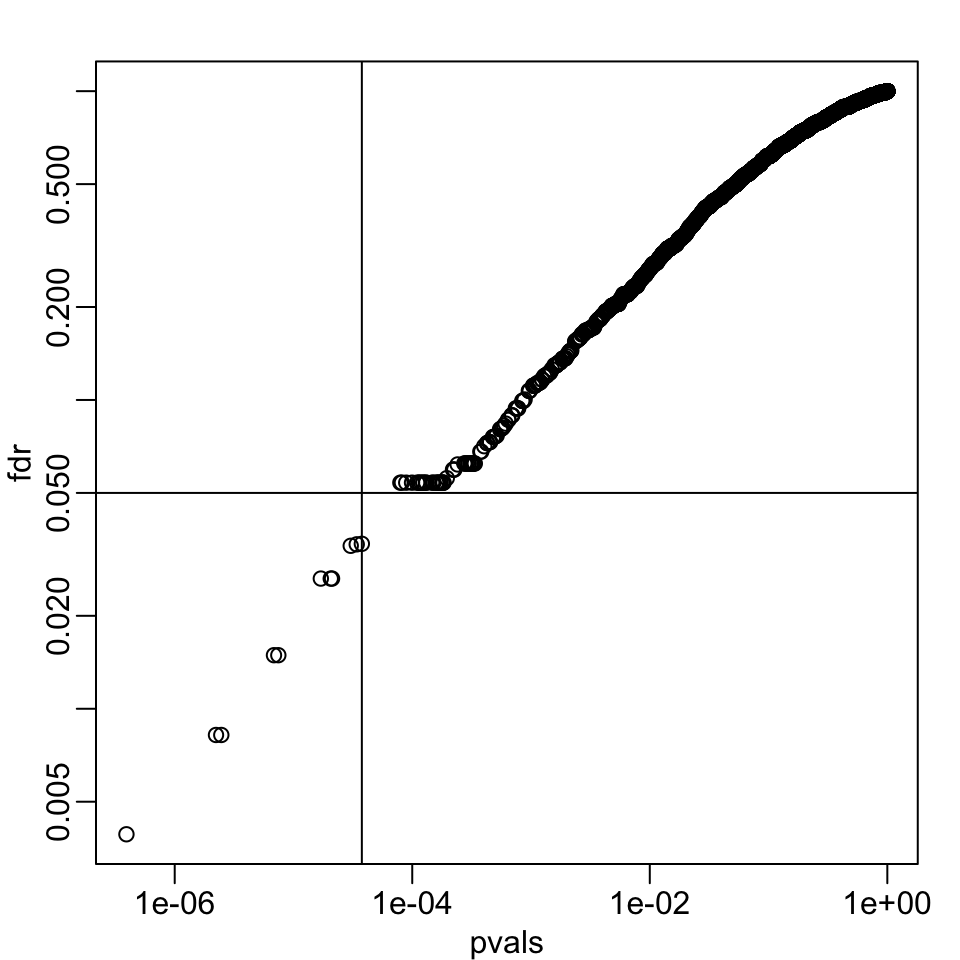

```r
fdr <- p.adjust(pvals, method="fdr")
mypar(1,1)
plot(pvals,fdr,log="xy")
abline(h=alpha,v=cutoff) ##cutoff was computed above
```

Run a Monte-Carlo simulation to confirm that the FDR is in fact lower than 0.05. Compute all p-values first, and then use these to decide which get called.

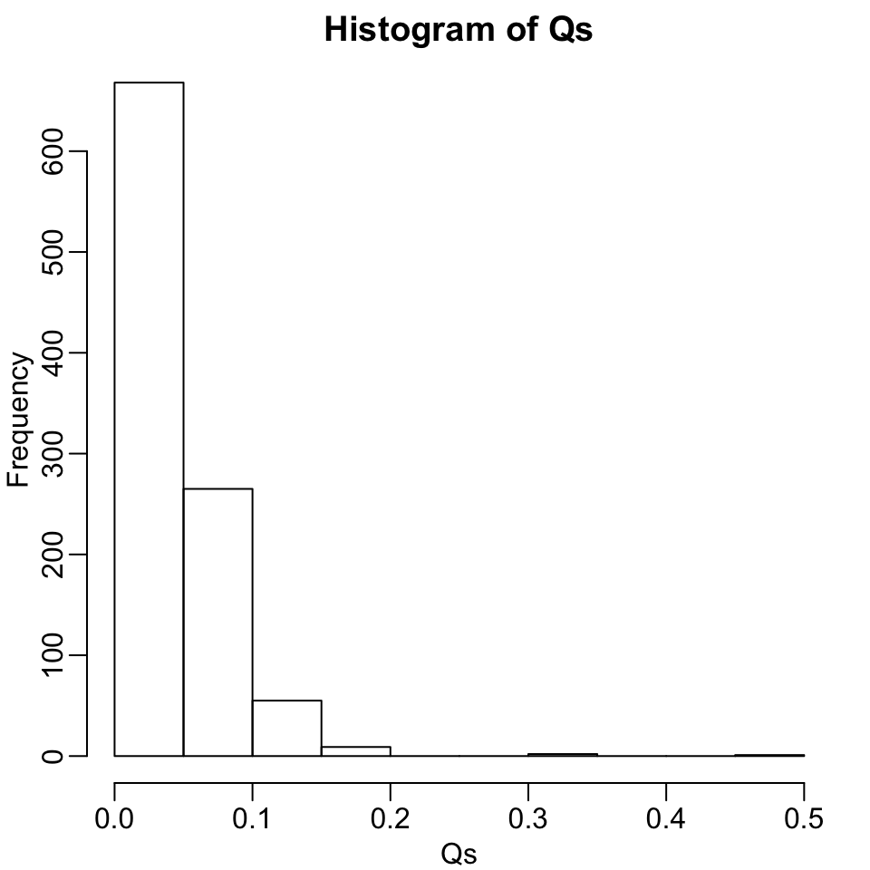

What is the estimated FDR value?

```
## [1] 0.03813818
```

The FDR is lower than 0.05. This is to be expected because we need to be conservative to assure the $FDR \leq 0.05$ for any value of $m_0$, such as for the extreme case where every hypothesis tested is null: $m=m_0$. If you re-do the simulation above for this case, you will find that the FDR increases.

In what fraction of the simulations you did not make any discovery?

[output not shown]